# Lecture 7: IV, dummy variables, F-tests and Macros

Jack Blundell

PUBLPOL 330D Applied Econometrics for Public Policy, Winter 2020

- My email: jackblundell@stanford.edu
- My office hours: 8.30 - 10.30am every Thursday at Econ 350 (Landau building)
- Section (further office hours): 2.30 - 3.20pm every Friday (Bass B312) **NOT THIS WEEK**

## 0. Preliminaries

- Thank you for your feedback.
- Please come to office hours / section, particularly if you are struggling with the material. If you cannot make the sessions then send me an email and we can meet.
- The section this Friday is rescheduled to next Monday at 2.30pm in Encina West 202.
- I will arrange one or more review sessions in the final week of classes before the take-home final.

## 1. Instrumental variables

We can use `ivregress` to estimate an instrumental variables regression.

Returning to the problem of estimating the **impact of maternal smoking on child birthweight**.

Lets say we are worried that even with control variables, we cannot estimate this causal impact.

Let us assume that we have access to data on **cigarette prices by state**, which vary due to tax differences. Since we do not have this variable, I simulate it:

```stata
. use "http://www.stata-press.com/data/r15/cattaneo2.dta", clear
(Excerpt from Cattaneo (2010) Journal of Econometrics 155: 138-154)

. gen price = -mbsmoke + rnormal(0,1)
```

We want to use `price`, which represents state-level cigarette prices, as an **instrumental variable** for mother smoking. The argument is that cigarette price affects mother smoking behavior, but does not affect child birthweight through any other mechanism.

The command to do this is:

```stata
. ivregress 2sls bweight (mbsmoke = price)

Instrumental variables (2SLS) regression          Number of obs   =      4,642
                                                  Wald chi2(1)    =      25.33
                                                  Prob > chi2     =     0.0000
                                                  R-squared       =     0.0340
                                                  Root MSE        =     568.83

─────────────┬────────────────────────────────────────────────────────────────
     bweight │      Coef.   Std. Err.      z    P>|z|     [95% Conf. Interval]
─────────────┼────────────────────────────────────────────────────────────────
     mbsmoke │   -299.053   59.42053    -5.03   0.000    -415.5151   -182.5909
       _cons │   3417.342   13.85722   246.61   0.000     3390.182    3444.501
─────────────┴────────────────────────────────────────────────────────────────
Instrumented:  mbsmoke
Instruments:   price
```

`bweight` is the outcome, `mbsmoke` is the variable we want to instrument for, and `price` is the instrumental variable.

We see that using the instrumental variable strategy, smoking has a statistically significant negative impact on birthweight.

We typically include a set of controls as follows:

```stata
. ivregress 2sls bweight medu fage fedu mmarried mhisp fhisp foreign birthmonth
> (mbsmoke = price)

Instrumental variables (2SLS) regression          Number of obs   =      4,642
                                                  Wald chi2(9)    =     195.41
                                                  Prob > chi2     =     0.0000
                                                  R-squared       =     0.0559
                                                  Root MSE        =     562.34

─────────────┬────────────────────────────────────────────────────────────────
     bweight │      Coef.   Std. Err.      z    P>|z|     [95% Conf. Interval]
─────────────┼────────────────────────────────────────────────────────────────
     mbsmoke │  -249.4624   63.27864    -3.94   0.000    -373.4863   -125.4385
        medu │   4.713528   4.139103     1.14   0.255    -3.398966    12.82602
        fage │   .1811978   1.082831     0.17   0.867    -1.941112    2.303507
        fedu │   2.622193   3.144285     0.83   0.404    -3.540492    8.784878
    mmarried │   162.4491    23.3281     6.96   0.000     116.7269    208.1713
       mhisp │    62.2423   68.34053     0.91   0.362    -71.70267    196.1873
       fhisp │   9.006227   63.74046     0.14   0.888    -115.9228    133.9352
     foreign │  -92.16012   39.94066    -2.31   0.021    -170.4424   -13.87786
  birthmonth │   .9211979   2.462629     0.37   0.708    -3.905466    5.747862
       _cons │   3193.868   60.72761    52.59   0.000     3074.844    3312.892
─────────────┴────────────────────────────────────────────────────────────────
Instrumented:  mbsmoke
Instruments:   medu fage fedu mmarried mhisp fhisp foreign birthmonth price
```

The effect persists when controls are included.

## 2. Dummy variables

A dummy variable is just an indicator which equals 1 if a certain condition is satisfied. In previous problems, ‘treatment’ has been a dummy variable.

Sometimes we have the choice of whether to include a variable as a continuous variable or as a series of dummies.

For example, we could regress birthweight on mothers age as follows, by including it as a continuous predictor:

```stata
. use "http://www.stata-press.com/data/r15/cattaneo2.dta", clear
(Excerpt from Cattaneo (2010) Journal of Econometrics 155: 138-154)

. keep if mage >= 18 & mage <=35
(488 observations deleted)
```

```stata
. reg bweight mage

      Source │       SS           df       MS      Number of obs   =     4,154
─────────────┼──────────────────────────────────   F(1, 4152)      =     25.24
       Model │  8114041.26         1  8114041.26   Prob > F        =    0.0000
    Residual │  1.3347e+09     4,152  321454.829   R-squared       =    0.0060
─────────────┼──────────────────────────────────   Adj R-squared   =    0.0058
       Total │  1.3428e+09     4,153  323331.204   Root MSE        =    566.97

─────────────┬────────────────────────────────────────────────────────────────
     bweight │      Coef.   Std. Err.      t    P>|t|     [95% Conf. Interval]
─────────────┼────────────────────────────────────────────────────────────────
        mage │   9.679711   1.926654     5.02   0.000     5.902437    13.45699
       _cons │   3114.394   51.57005    60.39   0.000      3013.29    3215.499
─────────────┴────────────────────────────────────────────────────────────────
```

```stata
. twoway lfit bweight mage, lcolor(black) ///
> graphregion(color(white))

. graph export "linear.png", replace
(file linear.png written in PNG format)
```

The fitted model looks like this:

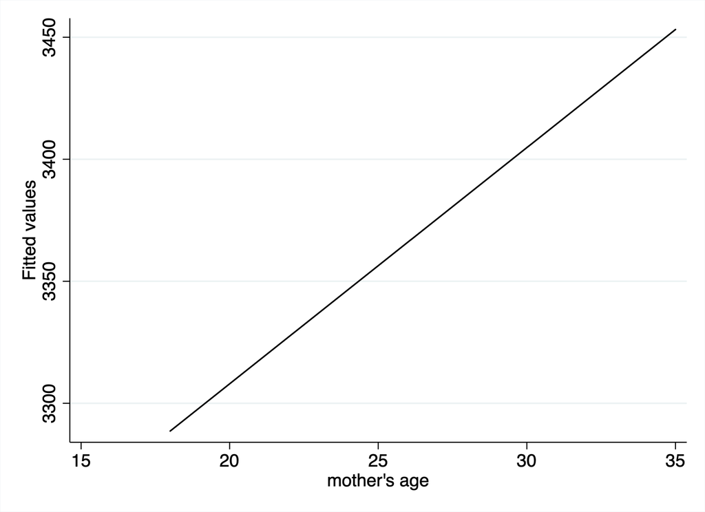

We could also regress birthweight on a series of dummies, with each dummy representing a single value of mother’s age. We do this by adding `i.` in front of the variable.

```stata
. reg bweight i.mage

      Source │       SS           df       MS      Number of obs   =     4,154
─────────────┼──────────────────────────────────   F(17, 4136)     =      2.15
       Model │  11740961.5        17  690644.796   Prob > F        =    0.0041
    Residual │  1.3311e+09     4,136  321821.453   R-squared       =    0.0087
─────────────┼──────────────────────────────────   Adj R-squared   =    0.0047
       Total │  1.3428e+09     4,153  323331.204   Root MSE        =    567.29

─────────────┬────────────────────────────────────────────────────────────────
     bweight │      Coef.   Std. Err.      t    P>|t|     [95% Conf. Interval]
─────────────┼────────────────────────────────────────────────────────────────
        mage │
         19  │   32.29816   63.86379     0.51   0.613    -92.90921    157.5055
         20  │  -6.559809   62.92476    -0.10   0.917    -129.9262    116.8066
         21  │   74.94038   62.80868     1.19   0.233     -48.1984    198.0792
         22  │   63.64096   61.79752     1.03   0.303    -57.51541    184.7973
         23  │   109.9243   60.67747     1.81   0.070    -9.036212    228.8847
         24  │   80.91053   60.09693     1.35   0.178    -36.91178    198.7328
         25  │   79.18255   59.53957     1.33   0.184    -37.54701    195.9121
         26  │   130.4079    58.9774     2.21   0.027     14.78048    246.0353
         27  │   152.4614   60.06033     2.54   0.011     34.71091     270.212
         28  │   116.7346   58.77504     1.99   0.047     1.503951    231.9653
         29  │   171.1589   58.80343     2.91   0.004     55.87256    286.4453
         30  │   108.4181   59.44139     1.82   0.068    -8.118954    224.9552
         31  │   154.6987    60.7184     2.55   0.011     35.65801    273.7394
         32  │    166.827    63.1027     2.64   0.008     43.11182    290.5422
         33  │   95.31767    65.8431     1.45   0.148    -33.77022    224.4056
         34  │   175.0332   68.57209     2.55   0.011     40.59505    309.4714
         35  │   217.3445    72.7538     2.99   0.003     74.70788     359.981
             │
       _cons │   3261.789   49.19055    66.31   0.000      3165.35    3358.229
─────────────┴────────────────────────────────────────────────────────────────
```

The next section of code generates a plot of the coefficients.

```stata
. regsave
```

```stata
. gen lower = coef - 1.96*stderr

. gen upper = coef + 1.96*stderr
```

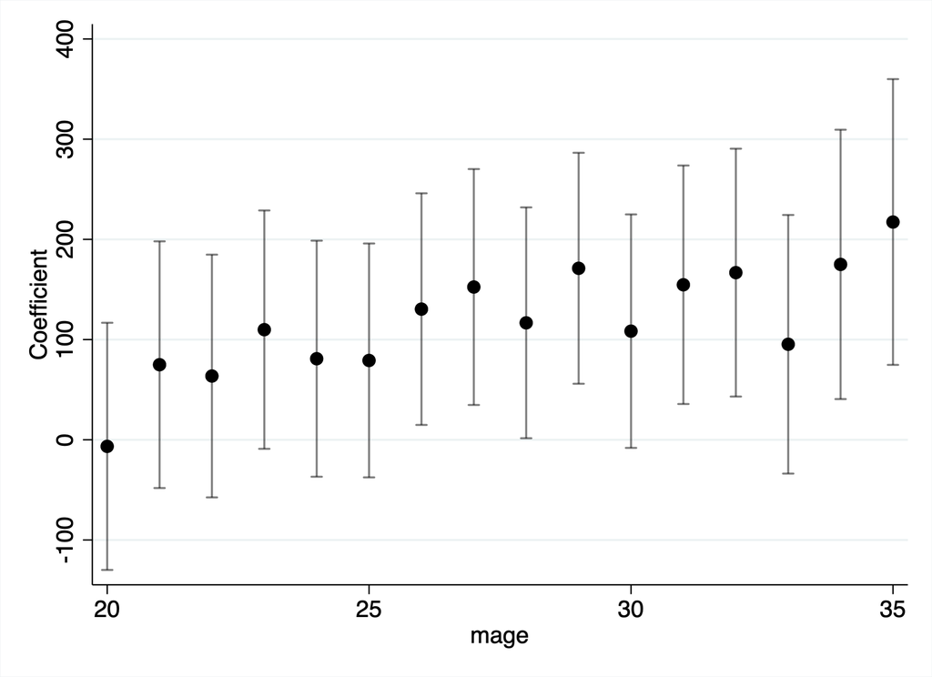

```stata
. gen mage = substr(var,1,2)

. destring mage, replace force
mage: contains nonnumeric characters; replaced as byte
(1 missing value generated)

. drop if mage < 20
(2 observations deleted)

. drop if mage == .
(1 observation deleted)

. twoway (scatter coef mage, mcolor(black)) ///
> (rcap lower upper mage, lcolor(black%50)), ///
> graphregion(color(white)) ///
> legend(off) ytitle("Coefficient")

. graph export "dummies.png", replace
(file dummies.png written in PNG format)
```

This allows a much **more flexible relationship**, but requires quite a lot of data.

## 3. F-tests

Let us consider the case where we are investigating the predictors of child birthweight.

We first run a regression of birthweight on a set of covariates:

```stata
. use "http://www.stata-press.com/data/r15/cattaneo2.dta", clear
(Excerpt from Cattaneo (2010) Journal of Econometrics 155: 138-154)

. reg bweight mage medu fage fedu mmarried mhisp fhisp foreign birthmonth

      Source │       SS           df       MS      Number of obs   =     4,642
─────────────┼──────────────────────────────────   F(9, 4632)      =     19.72
       Model │  57381997.5         9   6375777.5   Prob > F        =    0.0000
    Residual │  1.4975e+09     4,632  323294.957   R-squared       =    0.0369
─────────────┼──────────────────────────────────   Adj R-squared   =    0.0350
       Total │  1.5549e+09     4,641  335032.156   Root MSE        =    568.59

─────────────┬────────────────────────────────────────────────────────────────
     bweight │      Coef.   Std. Err.      t    P>|t|     [95% Conf. Interval]
─────────────┼────────────────────────────────────────────────────────────────
        mage │   2.447161   1.964603     1.25   0.213    -1.404396    6.298718
        medu │   7.291883   4.231819     1.72   0.085    -1.004499    15.58826
        fage │   -.797766   1.230483    -0.65   0.517    -3.210098    1.614567
        fedu │   5.691847   3.158015     1.80   0.072    -.4993671    11.88306
    mmarried │   193.6681   22.10056     8.76   0.000     150.3405    236.9958
       mhisp │   90.20593   68.79699     1.31   0.190    -44.66893    225.0808
       fhisp │   19.07074   64.45051     0.30   0.767     -107.283    145.4244
     foreign │  -75.96108   40.15636    -1.89   0.059    -154.6867    2.764513
  birthmonth │   .5428616      2.488     0.22   0.827    -4.334803    5.420527
       _cons │   3017.212   54.13426    55.74   0.000     2911.083    3123.341
─────────────┴────────────────────────────────────────────────────────────────
```

We can see that a number of the predictors are significant, but some are not.

We might want to test the null hypothesis that **all** of the coefficients are zero, rather than inspecting them individually.

We can do this using the following the regression with a `test` command, followed by the covariates:

```stata
. test mage medu fage fedu mmarried mhisp fhisp foreign birthmonth

 ( 1)  mage = 0
 ( 2)  medu = 0
 ( 3)  fage = 0
 ( 4)  fedu = 0
 ( 5)  mmarried = 0
 ( 6)  mhisp = 0
 ( 7)  fhisp = 0
 ( 8)  foreign = 0
 ( 9)  birthmonth = 0

       F(  9,  4632) =   19.72
            Prob > F =    0.0000
```

We reject the null hypothesis. The coefficients are jointly different to zero.

If testing with dummy coefficients, they are denoted by their level (number), a period, then the variable name. For example testing the coefficient on an education dummy where education equals 4, the test would be `test 4.educ`.

## 4. Macros

A macro is a way to store something in memory. They come in two forms: local or global. Here we only look at local macros. Locals only exist in the current context, meaning that you need to define them in your .do file each time you want to use them.

### 4.1 Storing text in macros

Lets first look at an example where we want to run a set of regressions with the same control variables. Rather than copy and pasting, we can store in a macro as follows:

```
local controls age educ male
```

You can then include these controls in a set of regressions. Note the use of the backtick when calling the local.

```
reg earnings `controls'
reg earnings `controls' if lagged_earnings < 20
reg earnings `controls' if age >= 20
```

This is equivalent to:

```
reg earnings age educ male
reg earnings age educ male if lagged_earnings < 20
reg earnings age educ male if age >= 20
```

This makes coding a lot easier. It reduces repetition and makes it easier to go back and change things for multiple lines of code

### 4.2 Storing results in macros

Another type of macro which we saw earlier in the course is used to store results. This type of macro tells Stata to evaluate whatever you put on the right hand side of `local name = XYZ`. That number will then be stored as a macro.

Heres an example where we store some results from a regression in a local macro. Note the difference between including the equals sign or not.

```stata
. sysuse auto, clear
(1978 Automobile Data)
```

```stata
. regress mpg weight

      Source │       SS           df       MS      Number of obs   =        74
─────────────┼──────────────────────────────────   F(1, 72)        =    134.62
       Model │   1591.9902         1   1591.9902   Prob > F        =    0.0000
    Residual │  851.469256        72  11.8259619   R-squared       =    0.6515
─────────────┼──────────────────────────────────   Adj R-squared   =    0.6467
       Total │  2443.45946        73  33.4720474   Root MSE        =    3.4389

─────────────┬────────────────────────────────────────────────────────────────
         mpg │      Coef.   Std. Err.      t    P>|t|     [95% Conf. Interval]
─────────────┼────────────────────────────────────────────────────────────────
      weight │  -.0060087   .0005179   -11.60   0.000    -.0070411   -.0049763
       _cons │   39.44028   1.614003    24.44   0.000     36.22283    42.65774
─────────────┴────────────────────────────────────────────────────────────────
```

```stata
. local rsqf e(r2)
```

```stata
. local rsqv = e(r2)
```

```stata
. display `rsqf'       // this gives the current R-squared
.65153125
```

```stata
. display `rsqv'       // this gives the same
.65153125
```

```stata
. regress mpg weight foreign

      Source │       SS           df       MS      Number of obs   =        74
─────────────┼──────────────────────────────────   F(2, 71)        =     69.75
       Model │   1619.2877         2  809.643849   Prob > F        =    0.0000
    Residual │  824.171761        71   11.608053   R-squared       =    0.6627
─────────────┼──────────────────────────────────   Adj R-squared   =    0.6532
       Total │  2443.45946        73  33.4720474   Root MSE        =    3.4071

─────────────┬────────────────────────────────────────────────────────────────
         mpg │      Coef.   Std. Err.      t    P>|t|     [95% Conf. Interval]
─────────────┼────────────────────────────────────────────────────────────────
      weight │  -.0065879   .0006371   -10.34   0.000    -.0078583   -.0053175
     foreign │  -1.650029   1.075994    -1.53   0.130      -3.7955    .4954422
       _cons │    41.6797   2.165547    19.25   0.000     37.36172    45.99768
─────────────┴────────────────────────────────────────────────────────────────
```

```stata
. display `rsqf'       // the gives the new R-squared
.66270291
```

```stata
. display  `rsqv'       // this gives the old R-squared
.65153125
```